# Turaga_FinalProject

2023-11-28

Task One (Prescriptive Part):

1. Read in data set

```r
library(tidyverse)
url <- "https://www4.stat.ncsu.edu/~online/ST308/Data/asturaga_house.csv"
asturaga_data <- read_csv(url)
```

2. Create new tibble to alter data (remove data & create new variables)

```r
alter_data <- asturaga_data %>%
 #remove observations w/ these conditions
  filter(!(MasVnrType == "Stone" | OpenPorchSF <= 0)) %>%
 #create new variable
  mutate(newSalePrice = SalePrice / 100000) %>%
 #remove these two variables
  select(-BedroomAbvGr, -LandSlope)

library(knitr)
kable(alter_data[1:10, 1:6])
```

| SalePrice | YearRemodAdd | BsmtFinSF1 | FirstFlrSF | OpenPorchSF | GarageYrBlt |
| --- | --- | --- | --- | --- | --- |
| 223500 | 2002 | 486 | 920 | 42 | 2001 |
| 140000 | 1970 | 216 | 961 | 35 | 1998 |
| 250000 | 2000 | 655 | 1145 | 84 | 2000 |
| 143000 | 1995 | 732 | 796 | 30 | 1993 |
| 118000 | 1950 | 851 | 1077 | 4 | 1939 |
| 157000 | 1960 | 733 | 1253 | 213 | 1960 |
| 132000 | 2001 | 0 | 854 | 112 | 1991 |
| 325300 | 2006 | 0 | 1158 | 154 | 2005 |
| 230000 | 2002 | 0 | 1795 | 159 | 2002 |
| 134800 | 2000 | 234 | 900 | 32 | 2005 |

3. Produce summary statistics

```r
summary_house <- alter_data %>%
  group_by(LotConfig) %>%
  summarize(SalePrice_mean = mean(SalePrice),
            SalePrice_sd = sd(SalePrice),
            SalePrice_q1 = quantile(SalePrice, 0.25),
            SalePrice_q3 = quantile(SalePrice, 0.75),
            YearRemodAdd_mean = mean(YearRemodAdd),
            YearRemodAdd_sd = sd(YearRemodAdd),
            YearRemodAdd_q1 = quantile(YearRemodAdd, 0.25),
            YearRemodAdd_q3 = quantile(YearRemodAdd, 0.75),
            BsmtFinSF1_mean = mean(BsmtFinSF1),
            BsmtFinSF1_sd = sd(BsmtFinSF1),
            BsmtFinSF1_q1 = quantile(BsmtFinSF1, 0.25),
            BsmtFinSF1_q3 = quantile(BsmtFinSF1, 0.75))
kable(summary_house)
```

| LotConfig | SalePrice_mean | SalePrice_sd | SalePrice_q1 | SalePrice_q3 | YearRemodAdd_mean | YearRemodAdd_sd | YearRemodAdd_q1 | YearRemodAdd_q3 | BsmtFinSF1_mean | BsmtFinSF1_sd | BsmtFinSF1_q1 | BsmtFinSF1_q3 |
| --- | --- | --- | --- | --- | --- | --- | --- | --- | --- | --- | --- | --- |
| Corner | 207763.8 | 82992.55 | 157500 | 241000.0 | 1990.011 | 17.595135 | 1978.00 | 2004 | 410.7473 | 447.9117 | 0.0 | 716.5 |
| CulDSac | 234727.0 | 75648.00 | 189500 | 269842.5 | 1994.969 | 12.243456 | 1993.75 | 2003 | 501.9375 | 496.7901 | 0.0 | 942.5 |
| FR2or3 | 202460.0 | 43640.53 | 178700 | 221500.0 | 1996.867 | 8.830682 | 1995.50 | 2002 | 521.5333 | 414.9724 | 108.5 | 713.0 |
| Inside | 196727.2 | 69003.32 | 149800 | 227750.0 | 1989.724 | 18.775767 | 1977.00 | 2004 | 452.7337 | 439.9939 | 0.0 | 757.5 |

4. Create a scatter plot

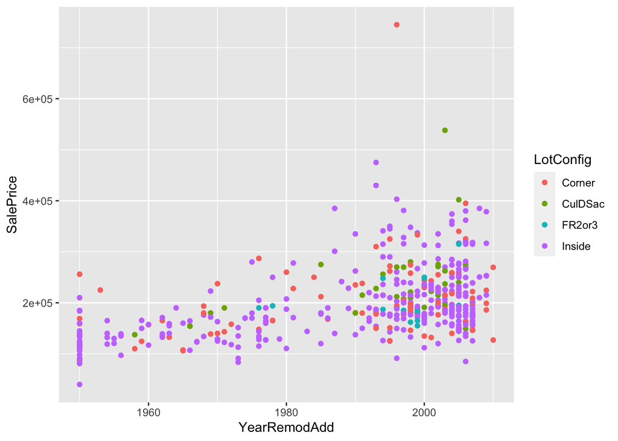

```r
ggplot(alter_data, aes(x = YearRemodAdd, y = SalePrice, color = LotConfig)) + geom_point()
```

5. Create the same plot (ExterCond)

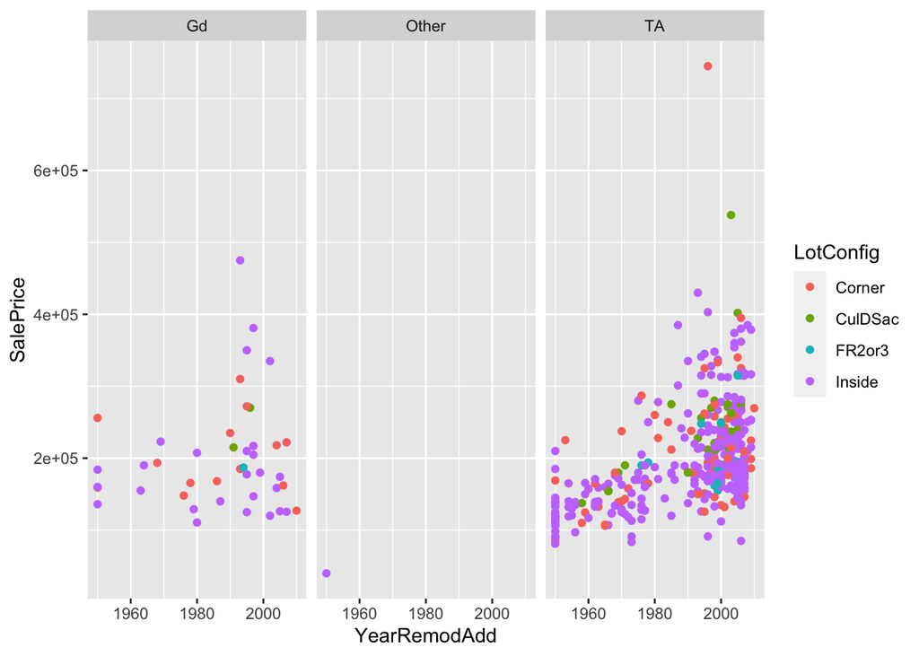

```r
ggplot(alter_data, aes(x = YearRemodAdd, y = SalePrice, color = LotConfig)) + geom_point() + facet_wrap(~ ExterCond)
```

Task Two (Open Ended Part):

1. I am currently a Computer Science major and am in the process of completing a CODA into Statistics. Both of these majors use and manipulate data in different ways but are essentially trying to do so in similar ways. Having the technical skillset and the statistical mindset is something that is very useful when it comes to working with big data and how that information helps to solve everyday problems.
2. The dataset I will be using is a dataset that has ranked the top universities all over the world and has given each one a score based on a few metrics. I think that this dataset is interesting because it can help to solve three main points of problems when looking to choices about higher education. It can be used to understood why some of the top universities are the top and what methods they are using to make their institutions so successful, it can be used to help with resource allocation to universities and understand where there is a gap, and finally with helping prospective students understand what universities are for them and how to take advantage of the opportunities each one can offer for their future. For the next question, I will only be using the data file from “The Global Top 10 data file”.

URL: https://www.kaggle.com/datasets/meeratif/top-universities-ranks-global-and-continent-wise?resource=download

Each variable describes the year from 2018 to 2024. The observations of those years describes the rankings of the universities each year based on factors such as academic performance, research output, and reputation. All the variables are numerical since they are rankings on a certain scale.

3. Read in the data

```r
library(readr)
global_university <- read_csv("/Users/amalaturaga/ST 308/Global Top 10.csv")
```

4. Create a custom function for summaries

```r
#Create a sample data frame
university_data <- data.frame(
  University = c(
    "Massachusetts Institute of Technology (MIT)",
    "University of Cambridge",
    "University of Oxford",
    "Harvard University",
    "Stanford University",
    "Imperial College London",
    "ETH Zurich",
    "National University of Singapore",
    "University College London",
    "University of California, Berkeley"
  ),
  Year_2018 = c(1, 2, 3, 4, 5, 6, 7, 8, 9, NA),
  Year_2019 = c(1, 2, 4, 5, 3, 6, 9, 11, 8, NA),
  Year_2020 = c(1, 3, 1, 5, 3, 7, 8, 11, 8, NA),
  Year_2021 = c(1, 7, 5, 3, 2, 8, 6, 11, 10, NA),
  Year_2022 = c(1, 7, 4, 3, 2, 9, 6, 11, 8, NA),
  Year_2023 = c(1, 6, 5, 3, 2, 8, 7, 11, 10, NA),
  Year_2024 = c(1, 5, 6, 3, 2, 8, 10, 15, 7, NA)
)

#Function to compute summary stats
summary_stats <- function(data, columns = NULL) {
  #All columns used except for header if not specified
  if (is.null(columns)) {
    columns <- names(data)[-1]
  }

  #Summary statistics for numeric columns (years)
  numeric_summary <- data %>%
    summarise_at(vars(all_of(columns)), list(
      Mean = ~mean(., na.rm = TRUE),
      Median = ~median(., na.rm = TRUE),
      SD = ~sd(., na.rm = TRUE),
      IQR = ~IQR(., na.rm = TRUE),
      Quantile_0_1 = ~quantile(., 0.1, na.rm = TRUE),
      Quantile_0_9 = ~quantile(., 0.9, na.rm = TRUE)
    ))
  return(numeric_summary)
}
```

5. Apply functions in different scenarios

```r
#Scenario 1: Summary stats for one column (Year_2018)
summary_2018 <- summary_stats(university_data, columns = "Year_2018")
print(summary_2018)
```

```
##   Mean Median       SD IQR Quantile_0_1 Quantile_0_9
## 1    5      5 2.738613   4          1.8          8.2
```

```r
#Scenario 2: Summary stats for two columns (Year_2018 and Year_2019)
summary_2018_2019 <- summary_stats(university_data, columns = c("Year_2018", "Year_2019"))
print(summary_2018_2019)
```

```
##   Year_2018_Mean Year_2019_Mean Year_2018_Median Year_2019_Median Year_2018_SD
## 1              5       5.444444                5                5     2.738613
##   Year_2019_SD Year_2018_IQR Year_2019_IQR Year_2018_Quantile_0_1
## 1      3.35824             4             5                    1.8
##   Year_2019_Quantile_0_1 Year_2018_Quantile_0_9 Year_2019_Quantile_0_9
## 1                    1.8                    8.2                    9.4
```

```r
#Scenario 3: Summary stats for all numeric columns (all years)
summary_all_years <- summary_stats(university_data)
print(summary_all_years)
```

```
##   Year_2018_Mean Year_2019_Mean Year_2020_Mean Year_2021_Mean Year_2022_Mean
## 1              5       5.444444       5.222222       5.888889       5.666667
##   Year_2023_Mean Year_2024_Mean Year_2018_Median Year_2019_Median
## 1       5.888889       6.333333                5                5
##   Year_2020_Median Year_2021_Median Year_2022_Median Year_2023_Median
## 1                5                6                6                6
##   Year_2024_Median Year_2018_SD Year_2019_SD Year_2020_SD Year_2021_SD
## 1                6     2.738613      3.35824     3.492054     3.480102
##   Year_2022_SD Year_2023_SD Year_2024_SD Year_2018_IQR Year_2019_IQR
## 1     3.391165     3.480102     4.358899             4             5
##   Year_2020_IQR Year_2021_IQR Year_2022_IQR Year_2023_IQR Year_2024_IQR
## 1             5             5             5             5             5
##   Year_2018_Quantile_0_1 Year_2019_Quantile_0_1 Year_2020_Quantile_0_1
## 1                    1.8                    1.8                      1
##   Year_2021_Quantile_0_1 Year_2022_Quantile_0_1 Year_2023_Quantile_0_1
## 1                    1.8                    1.8                    1.8
##   Year_2024_Quantile_0_1 Year_2018_Quantile_0_9 Year_2019_Quantile_0_9
## 1                    1.8                    8.2                    9.4
##   Year_2020_Quantile_0_9 Year_2021_Quantile_0_9 Year_2022_Quantile_0_9
## 1                    8.6                   10.2                    9.4
##   Year_2023_Quantile_0_9 Year_2024_Quantile_0_9
## 1                   10.2                     11
```